# Bellabeat Case Study

Abhishek Salaria

2022-05-23

### Introduction

Bellabeat is a high-tech manufacturer of health-focused products for women. It is a successful small company, but they have the potential to become a larger player in the global smart device market. Urška Sršen, cofounder and Chief Creative Officer of Bellabeat, believes that analyzing smart device fitness data could help unlock new growth opportunities for the company.

### Business Requirement

In this case study we’ll analyze smart device data to gain insight into how consumers are using their smart devices. The insights will then help guide marketing strategy for the company. Analysis will be shared to the Bellabeat executive team along with high-level recommendations for Bellabeat’s marketing strategy.

### Ask Phase

We are asked to analyze smart device usage data in order to gain insight into how consumers use non-Bellabeat smart devices.  
**Questions**  
1. What are some trends in smart device usage?  
2. How could these trends apply to Bellabeat customers?  
3. How could these trends help influence Bellabeat marketing strategy?

### Process

#### Loading Packages

```r
library(tidyverse)
library(readr)
library(reshape2)
```

#### Loading Datasets

```r
dailyActivity <- read_csv("dailyActivity_merged.csv")
hourlyCalories <- read_csv("hourlyCalories_merged.csv")
sleepDay <- read_csv("sleepDay_merged.csv")
hourlyIntensities <- read_csv("hourlyIntensities_merged.csv")
```

#### Preprocessing hourlyCalories

Preprocessing hourlyCalories to seperate date, day and hour from activity date.

```r
hourlyCalories$ActivityDate <- strptime(hourlyCalories$ActivityHour,
                                        "%m/%d/%Y %I:%M:%S %p") %>%
  format("%m/%d/%Y") %>%
  as.Date(format = "%m/%d/%Y")

hourlyCalories$ActivityDay <- weekdays(as.Date(hourlyCalories$ActivityDate))

hourlyCalories$ActivityHour <- strptime(hourlyCalories$ActivityHour,
                                        "%m/%d/%Y %I:%M:%S %p") %>%
  format("%H:%M:%S")

hourlyCalories <- hourlyCalories %>%
  relocate(Calories, .after = ActivityDay)
```

#### Preprocessing sleepDay

Preprocessing SleepDay to convert the date to weekday format.

```r
sleepDay$SleepDay <- strptime(sleepDay$SleepDay,
                                        "%m/%d/%Y %I:%M:%S %p") %>%
  format("%m/%d/%Y") %>%
  as.Date(format = "%m/%d/%Y")

sleepDay$SleepDay <- weekdays(as.Date(sleepDay$SleepDay))
```

#### Preprocessing hourlyIntensities

Preprocessing hourlyIntensities to convert ActivityHour to hms format.

```r
hourlyIntensities$ActivityHour <- strptime(hourlyIntensities$ActivityHour,
                                        "%m/%d/%Y %I:%M:%S %p") %>%
  format("%H:%M:%S")
```

### Analysis and Share

**Walking Habit of Each Person.**

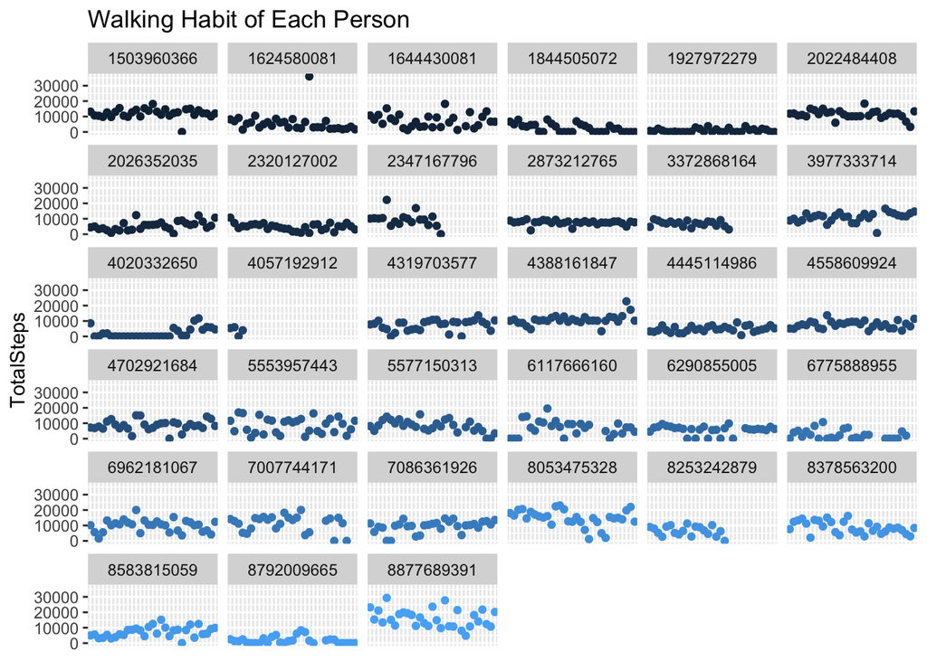

```r
ggplot(dailyActivity,aes(x=ActivityDate,y=TotalSteps,color=Id)) + geom_point() +
  theme(axis.text.x = element_text(angle = 90, vjust = 0.5, hjust=1),
        legend.position="none") +
  facet_wrap(~Id) + theme(axis.title.x=element_blank(),
                          axis.text.x=element_blank(),
                          axis.ticks.x=element_blank()) +
  ggtitle("Walking Habit of Each Person")
```

#### Summary of Daily Activities

```r
dailyActivity %>%
  select(TotalSteps,TrackerDistance,VeryActiveDistance,
         ModeratelyActiveDistance,LightActiveDistance, SedentaryActiveDistance,
         VeryActiveMinutes,FairlyActiveMinutes,LightlyActiveMinutes,
         SedentaryMinutes,Calories) %>%
  summary()
```

```
##    TotalSteps    TrackerDistance  VeryActiveDistance ModeratelyActiveDistance
##  Min.   :    0   Min.   : 0.000   Min.   : 0.000     Min.   :0.0000
##  1st Qu.: 3790   1st Qu.: 2.620   1st Qu.: 0.000     1st Qu.:0.0000
##  Median : 7406   Median : 5.245   Median : 0.210     Median :0.2400
##  Mean   : 7638   Mean   : 5.475   Mean   : 1.503     Mean   :0.5675
##  3rd Qu.:10727   3rd Qu.: 7.710   3rd Qu.: 2.053     3rd Qu.:0.8000
##  Max.   :36019   Max.   :28.030   Max.   :21.920     Max.   :6.4800
##  LightActiveDistance SedentaryActiveDistance VeryActiveMinutes
##  Min.   : 0.000      Min.   :0.000000        Min.   :  0.00
##  1st Qu.: 1.945      1st Qu.:0.000000        1st Qu.:  0.00
##  Median : 3.365      Median :0.000000        Median :  4.00
##  Mean   : 3.341      Mean   :0.001606        Mean   : 21.16
##  3rd Qu.: 4.782      3rd Qu.:0.000000        3rd Qu.: 32.00
##  Max.   :10.710      Max.   :0.110000        Max.   :210.00
##  FairlyActiveMinutes LightlyActiveMinutes SedentaryMinutes    Calories
##  Min.   :  0.00      Min.   :  0.0        Min.   :   0.0   Min.   :   0
##  1st Qu.:  0.00      1st Qu.:127.0        1st Qu.: 729.8   1st Qu.:1828
##  Median :  6.00      Median :199.0        Median :1057.5   Median :2134
##  Mean   : 13.56      Mean   :192.8        Mean   : 991.2   Mean   :2304
##  3rd Qu.: 19.00      3rd Qu.:264.0        3rd Qu.:1229.5   3rd Qu.:2793
##  Max.   :143.00      Max.   :518.0        Max.   :1440.0   Max.   :4900
```

#### Positive Relationship between Total Steps & Total Distance

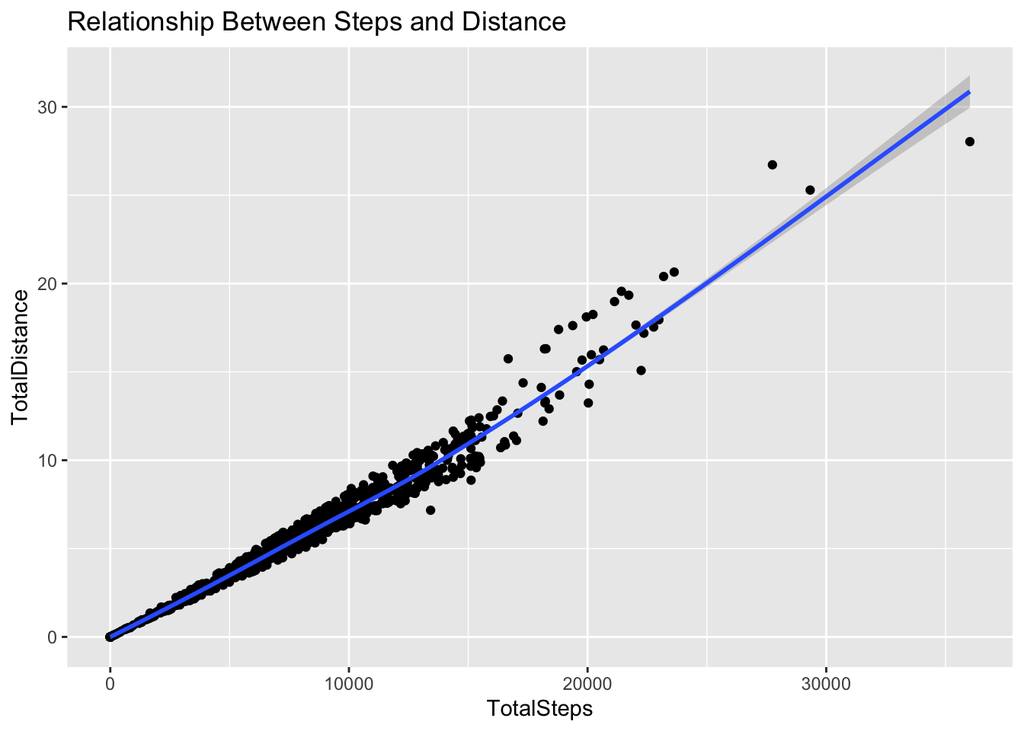

```r
ggplot(dailyActivity,aes(x=TotalSteps,y=TotalDistance)) + geom_point() + geom_smooth() +
  ggtitle("Relationship Between Steps and Distance")
```

#### Positive Relationship between Total Steps & Calories Burnt

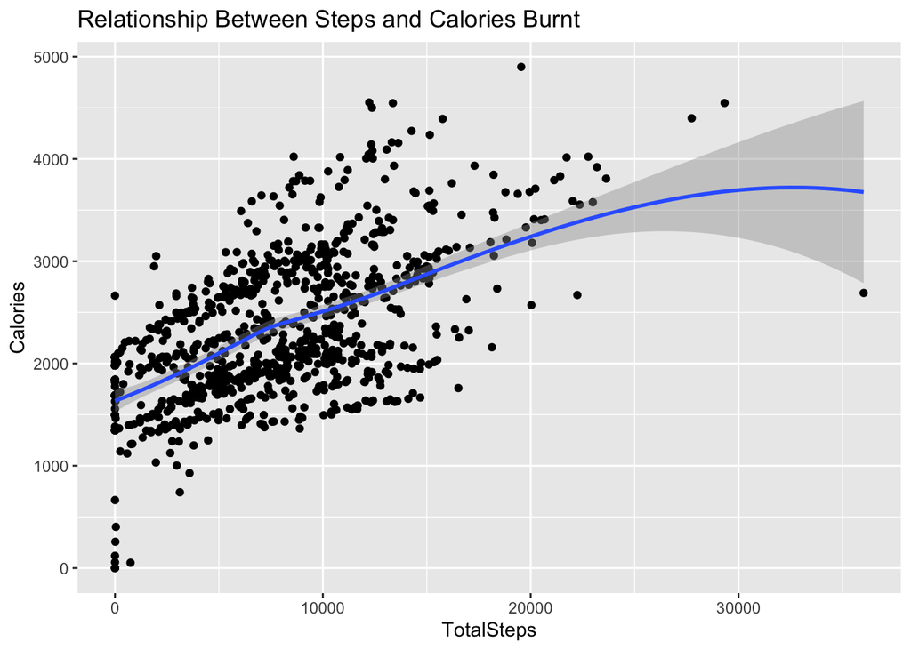

```r
ggplot(dailyActivity,aes(x=TotalSteps,y=Calories)) + geom_point() + geom_smooth() +
  ggtitle("Relationship Between Steps and Calories Burnt")
```

#### Hourly Average Calories Burnt

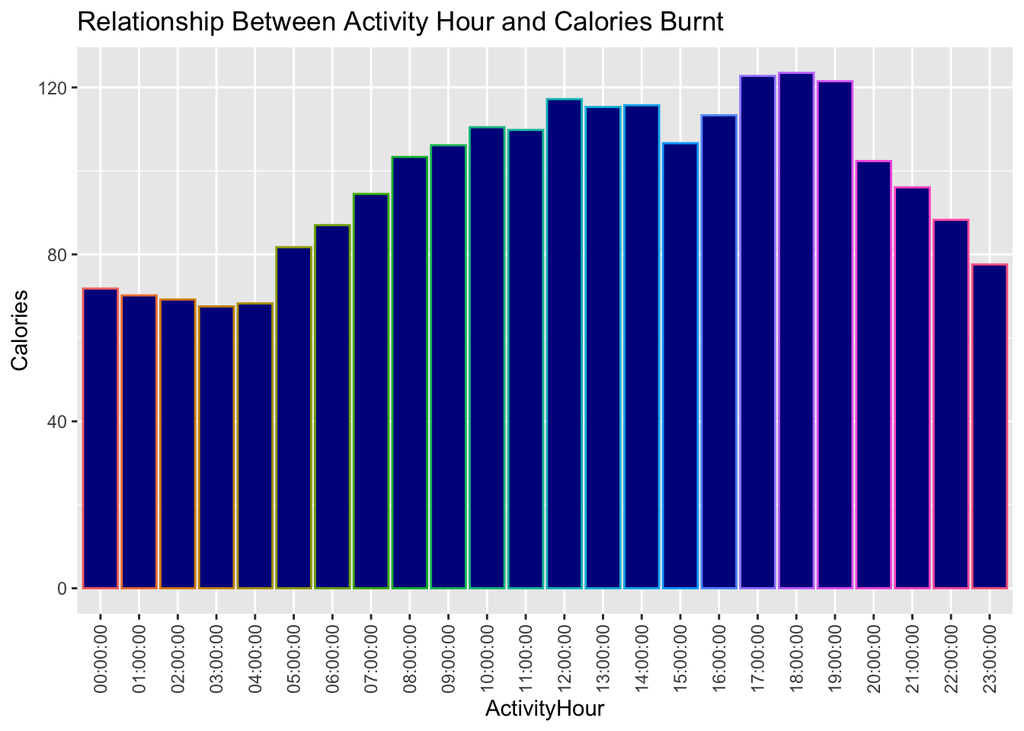

```r
average_hourly_Data <- hourlyCalories %>%
  select(ActivityHour,Calories) %>%
  group_by(ActivityHour) %>%
  summarise_all(.funs = mean)

ggplot(average_hourly_Data,aes(x=ActivityHour,y=Calories,color=ActivityHour)) +
  geom_bar(stat = "identity", fill='#00008B') +
  theme(axis.text.x = element_text(angle = 90, vjust = 0.5, hjust=1),
        legend.position="none") +
  ggtitle("Relationship Between Activity Hour and Calories Burnt")
```

**Summary of Calories Burnt Hourly**

```r
average_hourly_Data %>%
  select(Calories) %>%
  summary()
```

```
##     Calories
##  Min.   : 67.54
##  1st Qu.: 80.68
##  Median :102.85
##  Mean   : 97.50
##  3rd Qu.:113.82
##  Max.   :123.49
```

#### Daily Average Calories Burnt

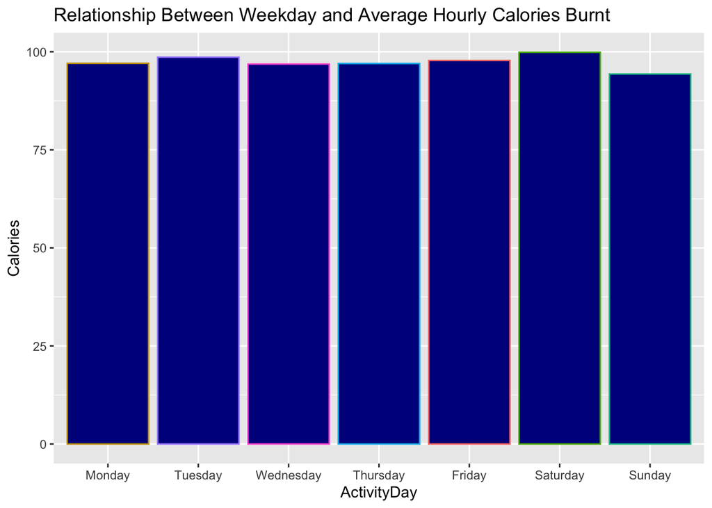

```r
average_daily_Data <- hourlyCalories %>%
  select(ActivityDay,Calories) %>%
  group_by(ActivityDay) %>%
  summarise_all(.funs = mean)

ggplot(average_daily_Data,aes(x=ordered(ActivityDay,
                                        levels=c("Monday", "Tuesday", "Wednesday", "Thursday",
                                                 "Friday", "Saturday", "Sunday")),
                              y=Calories,color=ActivityDay)) +
  geom_bar(stat = "identity", fill='#00008B') + labs(x = "ActivityDay") +
  theme(legend.position="none") +
  ggtitle("Relationship Between Weekday and Average Hourly Calories Burnt")
```

**Summary of Calories Burnt Daily**

```r
average_daily_Data %>%
  select(Calories) %>%
  summary()
```

```
##     Calories
##  Min.   :94.34
##  1st Qu.:96.94
##  Median :97.05
##  Mean   :97.36
##  3rd Qu.:98.20
##  Max.   :99.87
```

#### Daily Sleeping Habit

```r
average_sleep_Data <- sleepDay %>%
  select(SleepDay,TotalMinutesAsleep,TotalTimeInBed) %>%
  group_by(SleepDay) %>%
  summarise_all(.funs = mean)
average_sleep_Data$TimeTakenToSleep <- average_sleep_Data$TotalTimeInBed - average_sleep_Data$TotalMinutesAsleep
```

**Total Minutes Slept Each day**

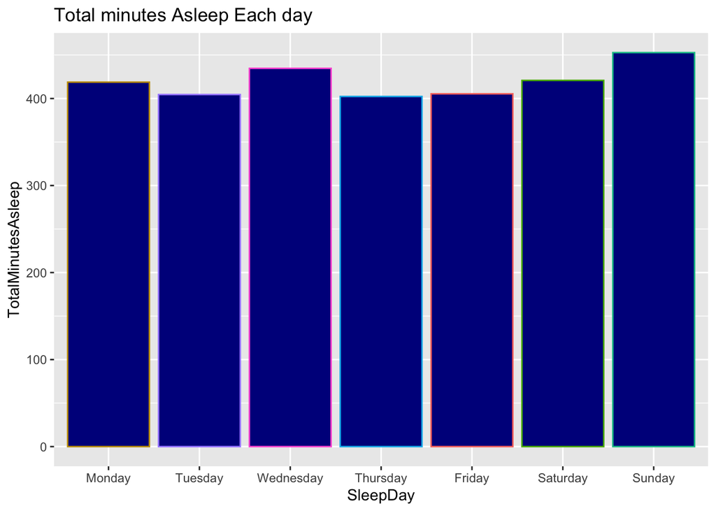

```r
ggplot(average_sleep_Data,aes(x=ordered(SleepDay,
                                        levels=c("Monday", "Tuesday", "Wednesday", "Thursday",
                                                 "Friday", "Saturday", "Sunday")),
                              y=TotalMinutesAsleep,color=SleepDay)) +
  geom_bar(stat = "identity", fill='#00008B') + labs(x = "SleepDay") +
  theme(legend.position="none") +
  ggtitle("Total minutes Asleep Each day")
```

**Total Time Taken to Sleep Each day**

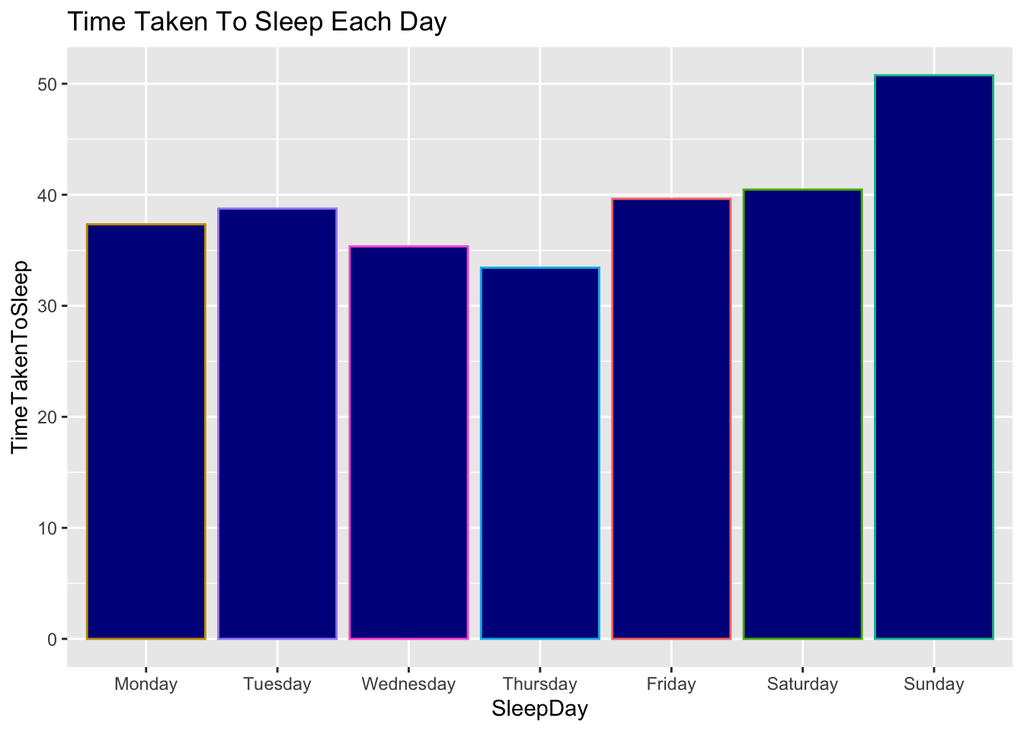

```r
ggplot(average_sleep_Data,aes(x=ordered(SleepDay,
                                        levels=c("Monday", "Tuesday", "Wednesday", "Thursday",
                                                 "Friday", "Saturday", "Sunday")),
                              y=TimeTakenToSleep,color=SleepDay)) +
  geom_bar(stat = "identity", fill='#00008B') + labs(x = "SleepDay") +
  theme(legend.position="none") +
  ggtitle("Time Taken To Sleep Each Day")
```

**Total Minutes Slept vs Total Time in Bed Each day**

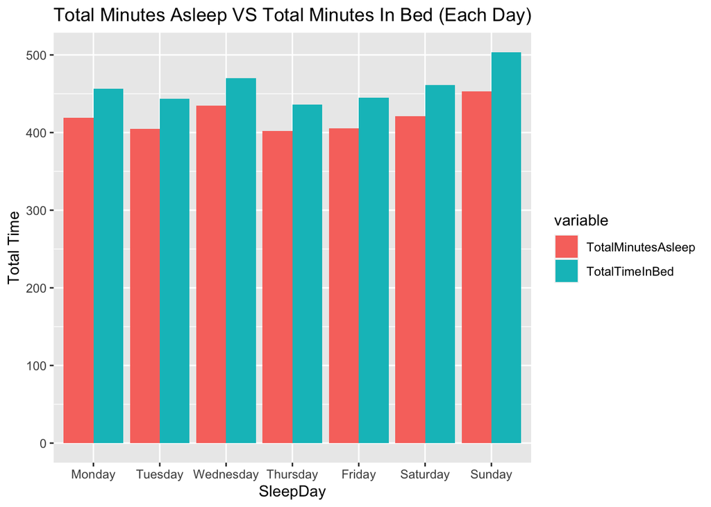

```r
ggplot(melt(average_sleep_Data[,c('SleepDay','TotalMinutesAsleep','TotalTimeInBed')]
            ,id.vars = 1),aes(x = ordered(SleepDay,
                                   levels=c("Monday", "Tuesday", "Wednesday", "Thursday",
                                            "Friday", "Saturday", "Sunday"))
                       ,y = value)) +
  geom_bar(aes(fill = variable),stat = "identity",position = "dodge") +
  labs(x = "SleepDay", y = "Total Time") +
  ggtitle("Total Minutes Asleep VS Total Minutes In Bed (Each Day)")
```

**Summary of Sleeping Habits**

```r
average_sleep_Data %>%
  select(TotalMinutesAsleep,TotalTimeInBed,TimeTakenToSleep) %>%
  summary()
```

```
##  TotalMinutesAsleep TotalTimeInBed  TimeTakenToSleep
##  Min.   :402.4      Min.   :435.8   Min.   :33.43
##  1st Qu.:405.0      1st Qu.:444.2   1st Qu.:36.34
##  Median :418.8      Median :456.2   Median :38.75
##  Mean   :419.9      Mean   :459.3   Mean   :39.39
##  3rd Qu.:427.7      3rd Qu.:465.7   3rd Qu.:40.05
##  Max.   :452.7      Max.   :503.5   Max.   :50.76
```

#### Hourly Intensities

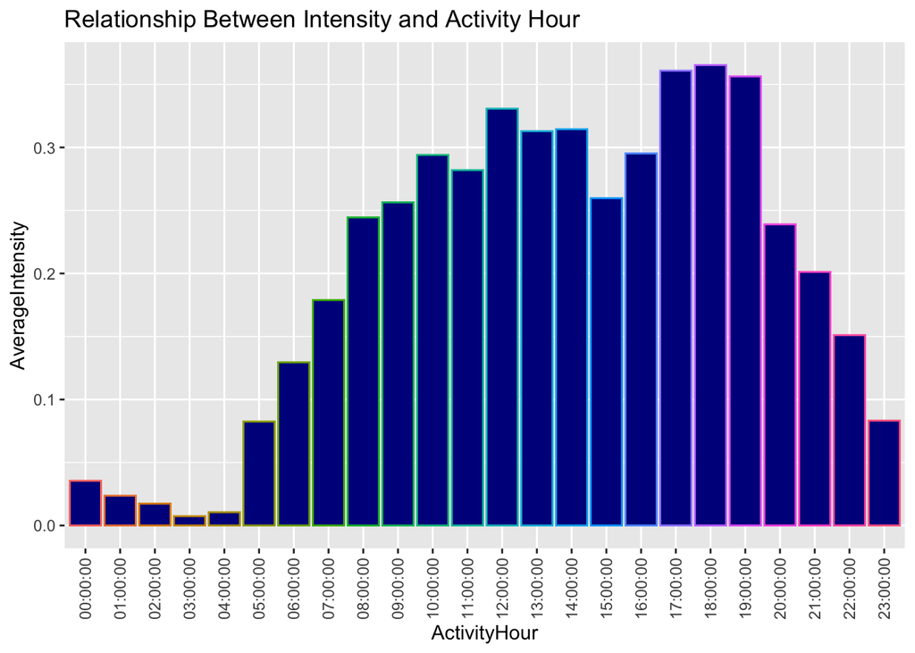

```r
average_Intensities_Data <- hourlyIntensities %>%
  select(ActivityHour,TotalIntensity,AverageIntensity) %>%
  group_by(ActivityHour) %>%
  summarise_all(.funs = mean)

ggplot(average_Intensities_Data,aes(x=ActivityHour,y=AverageIntensity, color=ActivityHour)) +
  geom_bar(stat = "identity", fill='#00008B') +
  theme(axis.text.x = element_text(angle = 90, vjust = 0.5, hjust=1),
        legend.position="none") +
  ggtitle("Relationship Between Intensity and Activity Hour")
```

### Act

#### Recommendations

1. People walks 7638 steps everyday which can be increased to 10000 Steps as per the recommendations of CDC to lower mortality rate and improve health. So, through bellabeat app, peoples can be notified about the number of steps that is required to be completed and also the benefits associated with it.
2. On an average people are sleeping around 7 hours as per our analysis that is the minimum time an adult should sleep as per CDC, so anyone sleeping less than that should be sent notification about improving sleeping time and also some posts showing benefits of a good sleep.
3. Peoples taking more time to sleep can be suggested with some useful tips such as yoga or healthy eating habits so as to improve their sleep time and overall health.
4. People can be given inapp rewards such as titles, increasing levels etc., based on different milestones they achieve everyday such as completing the number of required steps each day so as to encourage them.
5. In addition to all above recommendations, age related information of users can be collected so that recommendation according to age can be made, like number of steps, sleep required for teenage, adult and old people.